# Loss Functions

eulerr features multiple loss functions, which result in different diagrams for many combinations. In this vignette, we visualize the effect of the loss function on an example from an issue [posted on the GitHub repository for eulerr](https://github.com/jolars/eulerr/issues/93).

We list the combinations below, which consists of 5 different sets, *agc*, *camk*, *cmgc*, and *tk*.

```r
combos <- c(
  "agc" = 9,
  "camk" = 17,
  "cmgc" = 16,
  "tk" = 16,
  "tkl" = 23,
  "agc&camk" = 1,
  "camk&tk" = 1,
  "tk&tkl" = 1,
  "camk&cmgc&tkl" = 1,
  "camk&tk&tkl" = 2,
  "agc&camk&tk&tkl" = 1,
  "camk&cmgc&tk&tkl" = 3,
  "agc&camk&cmgc&tk&tkl" = 1
)
```

Notice that the sizes of most of the intersections are small compared to the size of the sets themselves and that many of the intersections are missing. Generating an exact Euler diagram that shows these intersections and at the same time omits the intersections that are here implicitly 0 is an impossible problem, which means that the best we can do is an approximation.

What kind of approximation we get depends on the loss functions we use. If we use the default, which in **eulerr** is the sums of squared errors, we will almost certainly get a design in which the intersections involving many sets are missing since including them inevitably leads to larger errors from having to include other intersections that are not present.

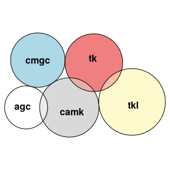

An Euler diagram fit to the combination given earlier on, showing that only 1-by-1 intersections are present. This fit uses the default loss function, the sum of squared errors.

```r
library(eulerr)

fit <- euler(combos)
plot(fit)
```

If we rather want a diagram that includes these intersections, despite leading to errors for the zero-intersections, then we need to switch the loss function we use. In **eulerr**, you can do so via the `loss` argument in `euler()`, which mirrors the loss functions provided by the underlying `eunoia` Rust crate.

Loss functions in **eulerr**

[output not shown]

The pre-1.0 `loss_aggregator` argument is deprecated; combine the behavior you want into a single `loss` value instead. For example `loss = "square"` together with `loss_aggregator = "sum"` is now simply `loss = "sum_squared"`, and `loss = "region"` with `loss_aggregator = "max"` is `loss = "diag_error"`.

To see what these different choices mean for the combination that we have looked at, we now refit the diagram for each loss.

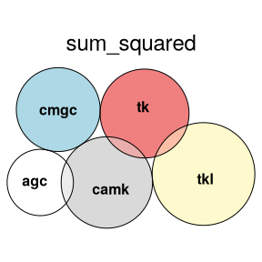

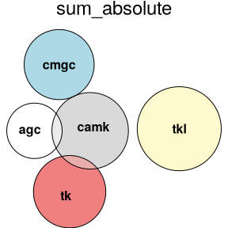

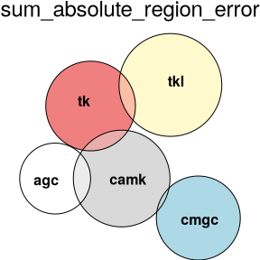

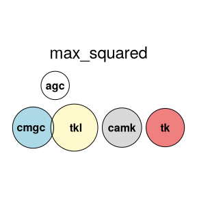

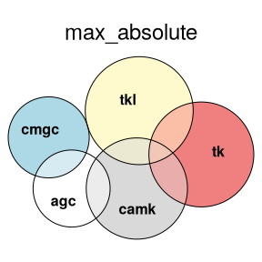

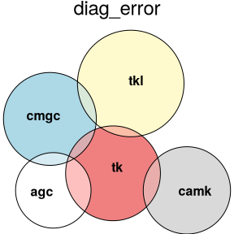

```r
losses <- c(
  "sum_squared",
  "sum_absolute",
  "sum_absolute_region_error",
  "max_squared",
  "max_absolute",
  "diag_error"
)

for (loss in losses) {
  fit <- euler(combos, loss = loss)
  print(plot(fit, main = loss))
}
```

Feel free to raise a request (or better yet, a pull request) at https://github.com/jolars/eulerr/issues if you know of any other loss function that you think should be included in the package.